# Orthogonal Nonlinear Least-Squares Regression with onls

Andrej-Nikolai Spiess

2026-10-29

```r
library(onls)
```

## 1. Why orthogonal regression?

Ordinary nonlinear least squares (`nls()`) assumes that the predictor $x$ is known exactly and all the “noise” lives in the response $y$: it fits $y = f(x, \theta) + \varepsilon$ by minimizing the *vertical* distance between each point and the curve,

$$\min_{\theta} \sum_{i=1}^n \left[y_i -
f(x_i, \theta)\right]^2.$$

In many real measurement situations – calibration curves, instrument comparisons, physical or chemical assays – **both** $x$ and $y$ carry measurement error. Orthogonal distance regression (ODR), also called *errors-in-variables* regression, accounts for this by allowing the model to also adjust the predictor: for each observation $i$, a *foot point* $\xi_i$ is found on the fitted curve/surface, and the model is fit by minimizing the distance from $(x_i, y_i)$ to $(\xi_i, f(\xi_i, \theta))$ instead of the purely vertical distance to $(x_i, f(x_i, \theta))$.

For a single, unweighted predictor this is literally the **shortest (perpendicular) distance** from each point to the curve – hence “orthogonal” regression. `onls()` generalizes this to multiple predictors and to heteroscedastic/weighted measurement error in both $x$ and $y$, and it does so in the manner of ODRPACK (Boggs, Byrd, Rogers & Schnabel): same objective, same weights, same covariance estimate.

Deming regression (linear, known ratio of $x$/$y$ variances) and Total Least Squares (linear, unweighted, multivariate) are both special cases of what `onls()` fits; we’ll see both later.

### 1.1 When is it worth it?

Classical least squares is *biased* when the predictors are measured with error. The coefficients of noisy predictors are attenuated towards zero; with correlated predictors the bias spills over to the other coefficients (even to those of nearly error-free predictors); and a nonlinear term such as $x_4^2$ is hit harder, because the error enters through the nonlinearity. Orthogonal regression puts the error where it belongs – on the *measured* predictor – and propagates it through the model function, which removes most of this bias. Two caveats matter in practice:

- the error standard deviations have to be **supplied** (`sigma_x`, `sigma_y`); they cannot be estimated from the data alone, and the result depends on them;
- the estimates have a larger variance than their least-squares counterparts, and they describe the relationship between the *true* quantities – if the goal is merely to predict $y$ from future *noisy* $x$, ordinary least squares is the better predictor.

A sensible workflow is therefore to fit both and compare: if the estimates hardly differ, measurement error does not matter for your problem.

## 2. The mathematics

### 2.1 The joint criterion

For a nonlinear model $y = f(x, \theta)$ with predictor vector $x \in \mathbb{R}^p$ and parameter vector $\theta$, let $Qyy_i$ be the response *precision* (inverse variance) for observation $i$, and $Qx_i$ its $p \times p$ predictor precision matrix. `onls()` uses the formulation of ODRPACK’s explicit ODR problem: the parameters and one correction $\delta_i = \xi_i - x_i$ per observation (so that $\xi_i = x_i + \delta_i$ is the foot point on the model surface) are estimated **simultaneously** by minimizing

$$S(\theta, \delta_1, \dots, \delta_n) =
\sum_{i=1}^{n}\left[Qyy_i\,\big(y_i - f(x_i + \delta_i, \theta)\big)^2 +
\delta_i^T Qx_i\,\delta_i\right].$$

For fixed $\theta$, minimizing $S$ over $\delta_i$ alone gives the weighted squared orthogonal distance of observation $i$ to the model surface,

$$d_i^2 = Qyy_i\left[y_i - f(\hat\xi_i,
\theta)\right]^2 + (\hat\xi_i - x_i)^T Qx_i (\hat\xi_i -
x_i),$$

so the estimate $\hat\theta$ is the minimizer of $\sum_i d_i^2$. The important point is that `onls()` does **not** solve a separate foot-point problem for every trial value of $\theta$: all $q + np$ unknowns ($q$ free parameters plus $n$ corrections of length $p$) are optimized at once. This is the “combined” approach of ODRPACK.

### 2.2 Where the precisions come from

$Qyy_i$ and $Qx_i$ are built from the `sigma_y`, `sigma_x`, and `weights` arguments to `onls()`:

- `sigma_y` (a standard deviation, not a variance): either one value shared by all observations, or a length-$n$ vector of observation-specific response error.
- `weights`: optional non-negative weights, combined multiplicatively, $Qyy_i = w_i / \sigma_{y,i}^2$. They act on the response side only.
- `sigma_x`: predictor measurement error, accepted as `NULL` (unit variance), a scalar (isotropic), a length-$p$ vector (diagonal, predictor-specific), a full $p \times p$ covariance matrix (allowing *correlated* predictor errors, $Qx = \Sigma_x^{-1}$), or an $n \times p$ matrix of observation-specific standard deviations.

When neither `sigma_x`, `sigma_y`, nor `weights` is supplied, $Qyy_i = 1$ and $Qx_i = I_p$ for every observation, and $d_i$ reduces to the plain Euclidean distance from $(x_i, y_i)$ to the curve – the classical, unweighted orthogonal-regression case.

ODRPACK’s own weights `WE` (response) and `WD` (predictor) are precisions, so they correspond to $Qyy_i = WE_i$ and $Qx_i = WD_i$; Section 3.4 shows how to pass them to `onls()`.

### 2.3 The algorithm, briefly

1. An ordinary (vertical) nonlinear fit via Levenberg-Marquardt (`minpack.lm::nlsLM()`) gives warm-start parameter values.
2. The joint problem is written as a nonlinear least-squares problem in the unknowns $(\theta, \delta)$ with the residual vector of length $n + np$

   $$r(\theta, \delta) =
   \Big(\big\{Qyy_i^{1/2}\,[y_i - f(x_i + \delta_i,
   \theta)]\big\}_{i=1}^{n},\;
   \big\{L_i\,\delta_i\big\}_{i=1}^{n}\Big), \qquad L_i^T L_i =
   Qx_i,$$

   so that $S = r^T r$, and is solved by Levenberg-Marquardt, starting at the warm-start values with all $\delta_i = 0$. The Jacobian of $r$ has the sparse “arrow” structure of ODRPACK, because each $\delta_i$ only affects observation $i$:

   $$J = \begin{pmatrix} -W_y^{1/2} F_\theta
   & -W_y^{1/2} G \\ 0 & L_x \end{pmatrix},$$

   with $F_\theta$ the derivatives of $f$ with respect to the parameters and $G$ the (block diagonal) derivatives with respect to the predictors, both at the current foot points. `onls()` supplies them exactly, by symbolic differentiation of the model formula and, if the formula cannot be differentiated (for example because it calls a user-defined function), by central finite differences.
3. Two algorithms compute the Levenberg-Marquardt steps (`algorithm`); the default `"auto"` uses `"structured"` for more than 100 observations or when parameter bounds are given, and `"dense"` otherwise. `"structured"` eliminates the $n$ small $p \times p$ blocks of the foot-point corrections from the normal equations, as ODRPACK does, and chooses the damping by MINPACK’s trust-region rule; its cost grows linearly with $n$. `"dense"` passes the full joint problem to `minpack.lm::nls.lm()`, at a cost growing with $n^3$; it is needed only for the foot-point bounds `extend`/`window` (used automatically then). Both stop when the convergence tolerances `ftol` and `ptol` (default `1e-10`) are met or after `control$outer_max` iterations (default 5000).
4. The parameter covariance is the ODRPACK (Gauss-Newton) covariance, i.e. the parameter block of $(J^T J)^{-1}$, which can be written with effective-variance weights as

   $$\widehat{\mathrm{Var}}(\hat\theta) =
   \hat\sigma^2\left(F_\theta^T W F_\theta\right)^{-1},\quad
   w_i = \left(Qyy_i^{-1} + g_i^T Qx_i^{-1} g_i\right)^{-1},\quad g_i =
   \nabla_x f(\hat\xi_i, \hat\theta).$$

   Here $\hat\sigma^2$ is the reduced chi-square when `known_sigma = FALSE`, and $1$ when the supplied precisions are taken as known (`known_sigma = TRUE`, the default as soon as `sigma_x` or `sigma_y` is given).
5. If some free parameters have no measurable influence on the fitted model (for example because a sigmoid has collapsed to a constant), `onls()` issues a warning – see Section 8.3.

### 2.4 Checking orthogonality

At the solution, $\partial S / \partial \delta_i = 0$ gives the stationarity (KKT) condition

$$Qx_i\,(\hat\xi_i - x_i) =
Qyy_i\,\big(y_i - f(\hat\xi_i, \hat\theta)\big)\,\nabla_x f(\hat\xi_i,
\hat\theta).$$

For unit precisions this says that the vector from the foot point to the observation is orthogonal to the model surface. With precisions, the same holds after each axis is rescaled by its precision (“whitened” coordinates $L_i x$ and $Qyy_i^{1/2} y$, with $L_i^T L_i = Qx_i$), where the weighted distance becomes an ordinary Euclidean one. `check_o()` therefore computes, for every observation, the angle $\alpha_i$ between the residual vector and the tangent space of the model surface in these coordinates: $90^\circ$ at a stationary foot point, for any number of predictors and any form of `sigma_x`, including correlated predictor errors. For one predictor and unit precisions this is the classical tangent angle. The tolerance is `tol_deg` (default $0.05^\circ$); observations that lie on the fitted surface have no angle and count as orthogonal. We’ll use it throughout.

## 3. A univariate example

We start with the classic `DNase` enzyme-linked immunosorbent assay data (from base R’s `nls` documentation) and a 3-parameter logistic model – a single predictor, no weighting, the simplest case where $d_i$ is literally the Euclidean distance to the curve.

```r
DNase1 <- subset(DNase, Run == 1)
set.seed(1)
DNase1$density <- sapply(DNase1$density, function(x) rnorm(1, x, 0.1 * x))

mod_uni <- onls(density ~ Asym / (1 + exp((xmid - log(conc)) / scal)),
                data = DNase1, start = list(Asym = 3, xmid = 0, scal = 1))
print(mod_uni)
```

```
#> Nonlinear orthogonal regression model
#>   model: density ~ Asym/(1 + exp((xmid - log(conc))/scal))
#>    data: DNase1
#>  Asym  xmid  scal
#> 3.303 2.352 1.315
#>  vertical residual sum-of-squares: 0.1832
#>  orthogonal residual sum-of-squares: 0.1782
#>  PASSED: 16 out of 16 fitted points are orthogonal.
#>
#> Number of iterations to convergence: 7
#> Convergence tolerance (ftol): 1e-10
```

```r
summary(mod_uni)
```

```
#>
#> Formula: density ~ Asym/(1 + exp((xmid - log(conc))/scal))
#>
#> Parameters:
#>      Estimate Std. Error t value Pr(>|t|)
#> Asym   3.3034     1.4820   2.229 0.044079 *
#> xmid   2.3520     1.1587   2.030 0.063351 .
#> scal   1.3150     0.3012   4.366 0.000764 ***
#> ---
#> Signif. codes:  0 '***' 0.001 '**' 0.01 '*' 0.05 '.' 0.1 ' ' 1
#>
#> Residual standard error of vertical distances: 0.1187 on 13 degrees of freedom
#> Residual standard error of orthogonal distances: 0.1171 on 13 degrees of freedom
#>
#> Number of iterations to convergence: 7
#> Convergence tolerance (ftol): 1e-10
```

The plot below shows the fitted orthogonal curve (red) alongside the ordinary vertical-least-squares warm-start curve (blue), with segments connecting each observation to its foot point. Because this fit is unweighted, `plot.onls()` uses a literal 1:1 axis aspect ratio by default – the segments should genuinely look perpendicular to the red curve.

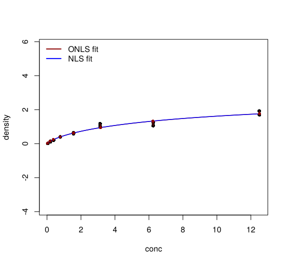

```r
plot(mod_uni)
```

`check_o()` confirms this numerically: for every observation, the angle between the tangent to the curve and the line to the observation should be within $0.05^\circ$ of a right angle.

```r
check_o(mod_uni, plot = FALSE)
```

```
#>           conc          x0    density         y0    alpha      df/dx Ortho
#> 1   0.04882812  0.02879479 0.01593503 0.03678759 89.99984 0.96071836  TRUE
#> 2   0.04882812  0.03010727 0.01833056 0.03804126 89.99986 0.94978583  TRUE
#> 3   0.19531250  0.17729284 0.11088889 0.14183707 89.99999 0.58225289  TRUE
#> 4   0.19531250  0.19170494 0.14378148 0.15012768 90.00000 0.56846042  TRUE
#> 5   0.39062500  0.37665149 0.21278786 0.24347577 89.99999 0.45534239  TRUE
#> 6   0.39062500  0.37074460 0.19735993 0.24077865 89.99999 0.45787592  TRUE
#> 7   0.78125000  0.77919269 0.39537608 0.40135468 89.99998 0.34411148  TRUE
#> 8   0.78125000  0.78111200 0.40161334 0.40201480 89.99998 0.34375231  TRUE
#> 9   1.56250000  1.56746128 0.64935297 0.62927803 89.99999 0.24713755  TRUE
#> 10  1.56250000  1.55369409 0.59040185 0.62586771 89.99999 0.24829245  TRUE
#> 11  3.12500000  3.16187573 1.17305050 0.94592294 90.00000 0.16235687  TRUE
#> 12  3.12500000  3.14090312 1.04002331 0.94251025 90.00000 0.16308705  TRUE
#> 13  6.25000000  6.24247076 1.25112651 1.32893758 89.99999 0.09676313  TRUE
#> 14  6.25000000  6.22426885 1.06191494 1.32717412 89.99999 0.09700388  TRUE
#> 15 12.50000000 12.50817620 1.92461305 1.76105267 89.99999 0.04998904  TRUE
#> 16 12.50000000 12.49708885 1.70231635 1.76049817 89.99999 0.05003562  TRUE
```

### 3.1 Foot points and orthogonal residuals

The foot points $(\hat\xi_i, f(\hat\xi_i, \hat\theta))$ are available through `x0()` and `y0()` in the original observation order, like every other per-observation result. Together with the observations they give the orthogonal distances by hand:

```r
FP <- data.frame(x = DNase1$conc, x0 = x0(mod_uni), y = DNase1$density, y0 = y0(mod_uni))
FP$dist <- sqrt((FP$x - FP$x0)^2 + (FP$y - FP$y0)^2)
head(FP)
```

```
#>            x         x0          y         y0        dist
#> 1 0.04882812 0.02879479 0.01593503 0.03678759 0.028916488
#> 2 0.04882812 0.03010727 0.01833056 0.03804126 0.027184228
#> 3 0.19531250 0.17729284 0.11088889 0.14183707 0.035811982
#> 4 0.19531250 0.19170494 0.14378148 0.15012768 0.007299918
#> 5 0.39062500 0.37665149 0.21278786 0.24347577 0.033719534
#> 6 0.39062500 0.37074460 0.19735993 0.24077865 0.047753701
```

```r
## for unit precisions, the sum of squared distances is the minimized objective
all.equal(sum(FP$dist^2), deviance_o(mod_uni))
```

```
#> [1] "Attributes: < target is NULL, current is list >"
```

`residuals_o()` returns the fitted, precision-weighted orthogonal distances $\hat d_i$ – the per-observation quantities that `deviance_o()` squares and sums – directly, also in the original observation order. For an unweighted single-predictor fit such as this one they are plain Euclidean distances, i.e. the `dist` column above:

```r
d_o <- residuals_o(mod_uni)
all.equal(d_o, FP$dist, check.attributes = FALSE)
```

```
#> [1] TRUE
```

```r
all.equal(sum(d_o^2), deviance_o(mod_uni))
```

```
#> [1] "Attributes: < target is NULL, current is list >"
```

```r
## side by side with the vertical residuals of the same fit
head(data.frame(vertical = residuals(mod_uni), orthogonal = d_o))
```

```
#>       vertical  orthogonal
#> 1 -0.038732828 0.028916488
#> 2 -0.036337299 0.027184228
#> 3 -0.041283634 0.035811982
#> 4 -0.008391046 0.007299918
#> 5 -0.037009708 0.033719534
#> 6 -0.052437638 0.047753701
```

If observations were dropped through `na.action = na.exclude`, `residuals_o()` re-inserts them as `NA` at their original positions, so that the result always lines up with the rows of the data:

```r
DNase1_na <- DNase1
DNase1_na$density[c(3, 10)] <- NA
mod_na <- onls(density ~ Asym / (1 + exp((xmid - log(conc)) / scal)),
               data = DNase1_na, start = list(Asym = 3, xmid = 0, scal = 1),
               na.action = na.exclude)
residuals_o(mod_na)
```

```
#>          1          2          3          4          5          6          7
#> 0.03139515 0.02973997         NA 0.01436914 0.04256587 0.05656476 0.01604731
#>          8          9         10         11         12         13         14
#> 0.01014890 0.01222736         NA 0.22537196 0.09402879 0.07872927 0.26707291
#>         15         16
#> 0.16397977 0.05803631
#> attr(,"label")
#> [1] "Orthogonal residuals from orthogonal model"
```

### 3.2 Plot options

`plot.onls()` draws the observations, the orthogonal fit (red), the ordinary vertical-least-squares warm-start fit (blue) and the segments to the foot points. Each of these can be switched off (`fitted.onls`, `fitted.nls`, `segments`), and `npoints` sets the resolution of the drawn curves. The orthogonality is easiest to judge for a steep curve. Here is a noisy quadratic:

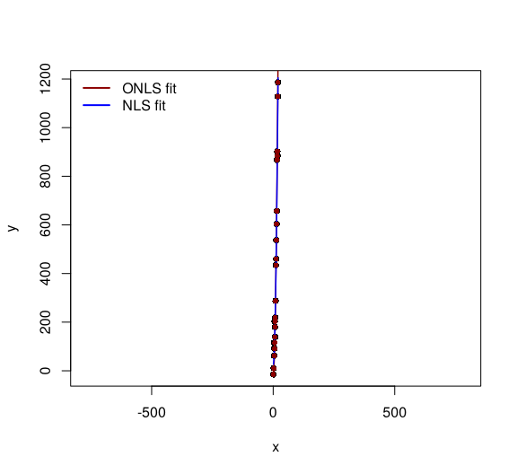

```r
set.seed(123)
x <- 1:20
y <- 10 + 3 * x^2 + rnorm(20, 0, 50)
DAT_quad <- data.frame(x, y)
mod_quad <- onls(y ~ a + b * x^2, data = DAT_quad, start = list(a = 10, b = 3))
plot(mod_quad)
```

To zoom into a region, supplying `xlim` alone is enough: a matching `ylim` is chosen automatically. A strict 1:1 axis ratio is generally not possible for a zoomed region, so it has to be switched off with `asp = FALSE`:

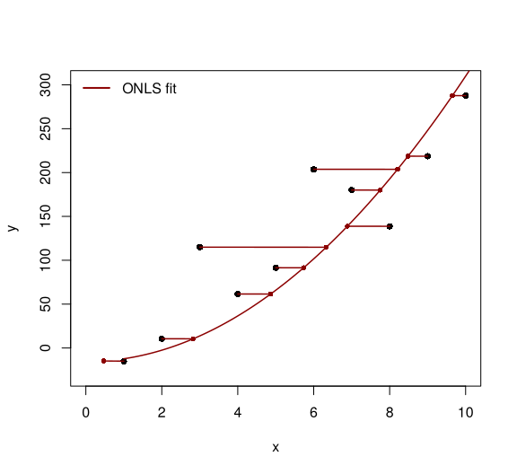

```r
plot(mod_quad, fitted.nls = FALSE, xlim = c(0, 10), asp = FALSE)
```

### 3.3 Adding measurement error: weighted regression

If the predictor and/or response measurement error is actually *known* (e.g. from instrument specifications or replicate measurements), supplying `sigma_x`/`sigma_y` gives a proper weighted orthogonal fit rather than treating all points as equally uncertain. A classic illustration is Pearson’s (1901) data with York’s (1966) weights – ten points with wildly different, known per-point standard deviations in both $x$ and $y$:

```r
x <- c(0.0, 0.9, 1.8, 2.6, 3.3, 4.4, 5.2, 6.1, 6.5, 7.4)
y <- c(5.9, 5.4, 4.4, 4.6, 3.5, 3.7, 2.8, 2.8, 2.4, 1.5)
sd_x <- 1 / sqrt(c(1000, 1000, 500, 800, 200, 80, 60, 20, 1.8, 1.0))
sd_y <- 1 / sqrt(c(1.0, 1.8, 4.0, 8.0, 20, 20, 70, 70, 100, 500))
DAT_py <- data.frame(x = x, y = y)

mod_w <- onls(y ~ b0 + b1 * x, data = DAT_py, start = list(b0 = 5, b1 = -0.5),
              sigma_x = sd_x, sigma_y = sd_y)
summary(mod_w)   # intercept 5.480 (0.295), slope -0.481 (0.058), matching York's published values
```

```
#>
#> Formula: y ~ b0 + b1 * x
#>
#> Parameters (variances known: z values):
#>    Estimate Std. Error z value Pr(>|z|)
#> b0  5.47991    0.29497  18.578   <2e-16 ***
#> b1 -0.48053    0.05799  -8.287   <2e-16 ***
#> ---
#> Signif. codes:  0 '***' 0.001 '**' 0.01 '*' 0.05 '.' 0.1 ' ' 1
#>
#> Residual standard error of vertical distances: 0.3585 on 8 degrees of freedom
#> Residual standard error of orthogonal distances: 1.218 on 8 degrees of freedom
#>
#> Number of iterations to convergence: 7
#> Convergence tolerance (ftol): 1e-10
```

For this weighted fit, `check_o()` measures the angle after rescaling each axis by its precision (in these whitened coordinates the weighted distance is Euclidean again), so 90 degrees is still the criterion:

```r
check_o(mod_w, plot = FALSE)
```

```
#>      x            x0   y       y0    alpha      df/dx Ortho
#> 1  0.0 -0.0002018208 5.9 5.480007 90.00000 -0.4805333  TRUE
#> 2  0.9  0.8996951674 5.4 5.047576 90.00000 -0.4805333  TRUE
#> 3  1.8  1.8008248014 4.4 4.614554 90.00000 -0.4805333  TRUE
#> 4  2.6  2.5982286299 4.6 4.231374 90.00000 -0.4805333  TRUE
#> 5  3.3  3.3185127438 3.5 3.885254 89.99999 -0.4805333  TRUE
#> 6  4.4  4.3620157262 3.7 3.383816 89.99999 -0.4805333  TRUE
#> 7  5.2  5.2799979510 2.8 2.942695 89.99999 -0.4805333  TRUE
#> 8  6.1  5.8662161319 2.8 2.660997 89.99998 -0.4805333  TRUE
#> 9  6.5  6.4159121599 2.4 2.396850 89.99999 -0.4805333  TRUE
#> 10 7.4  8.2747003350 1.5 1.503641 90.00000 -0.4805333  TRUE
```

### 3.4 ODRPACK’s weights `WE` and `WD`

ODRPACK takes a response weight `WE` and a predictor weight `WD` for every observation, both as precisions (inverse variances). In `onls()`, `WE` is passed as `weights` (with the default `sigma_y = 1`, or equivalently as `sigma_y = 1/sqrt(WE)`), and `WD` through `sigma_x = 1/sqrt(WD)` (for $p > 1$ an $n \times p$ matrix of $1/\sqrt{WD_{ij}}$). `known_sigma = FALSE` gives ODRPACK’s scaling of the standard errors by the residual variance.

```r
set.seed(7)
n <- 30
xt <- seq(0.5, 10, length.out = n)
WD <- runif(n, 0.5, 4)   # predictor weights
WE <- runif(n, 0.5, 4)   # response weights
x <- xt + rnorm(n, 0, 0.3 / sqrt(WD))
y <- 2 * exp(-0.3 * xt) + 0.5 + rnorm(n, 0, 0.03 / sqrt(WE))
DAT_we <- data.frame(x, y)

mod_we <- onls(y ~ a * exp(-b * x) + c, data = DAT_we,
               start = list(a = 1.5, b = 0.2, c = 0.3),
               weights = WE, sigma_x = 1 / sqrt(WD), known_sigma = FALSE)
summary(mod_we)   # 1.98131 (0.03347) / 0.28984 (0.01468) / 0.48480 (0.02986), as scipy.odr with we = WE, wd = WD
```

```
#>
#> Formula: y ~ a * exp(-b * x) + c
#>
#> Parameters:
#>   Estimate Std. Error t value Pr(>|t|)
#> a  1.98131    0.03347   59.20  < 2e-16 ***
#> b  0.28984    0.01468   19.74  < 2e-16 ***
#> c  0.48480    0.02986   16.23 1.87e-15 ***
#> ---
#> Signif. codes:  0 '***' 0.001 '**' 0.01 '*' 0.05 '.' 0.1 ' ' 1
#>
#> Residual standard error of vertical distances: 0.06119 on 27 degrees of freedom
#> Residual standard error of orthogonal distances: 0.05895 on 27 degrees of freedom
#>
#> Number of iterations to convergence: 4
#> Convergence tolerance (ftol): 1e-10
```

The minimized objective is exactly the ODRPACK objective $\sum WE\,\varepsilon^2 + WD\,\delta^2$:

```r
f <- function(x, b) b[1] * exp(-b[2] * x) + b[3]
xi <- mod_we$xi[, 1]
all.equal(sum(WE * (y - f(xi, coef(mod_we)))^2 + WD * (xi - x)^2), mod_we$objective)
```

```
#> [1] TRUE
```

## 4. Reference problems from the literature

`onls()` reproduces the published results of the standard ODRPACK test problems. A few of them are shown here; `doGauge()` runs all reference comparisons of the package (published results, closed-form solutions, ODRPACK and the NIST certified values) and reports each as PASS, NOTE or DIFF.

### 4.1 ODRPACK guide, example 2.C.i

```r
x <- c(0, 0, 5, 7, 7.5, 10, 16, 26, 30, 34, 34.5, 100)
y <- c(1265, 1263.6, 1258, 1254, 1253, 1249.8, 1237, 1218, 1220.6, 1213.8, 1215.5, 1212)
DAT_guide <- data.frame(x, y)

mod_guide <- onls(y ~ b1 + b2 * (exp(b3 * x) - 1)^2, data = DAT_guide,
                  start = list(b1 = 1500, b2 = -50, b3 = -0.1))
deviance_o(mod_guide)   # 21.445, as on page 47 of the guide
```

```
#> [1] 21.4455
#> attr(,"label")
#> [1] "Deviance (RSS) of orthogonal residuals from orthogonal model"
```

```r
summary(mod_guide)      # 1264.65481 (1.03492) / -54.01838 (1.583992) / -0.08785 (6.33222E-3), as on page 48
```

```
#>
#> Formula: y ~ b1 + b2 * (exp(b3 * x) - 1)^2
#>
#> Parameters:
#>      Estimate Std. Error t value Pr(>|t|)
#> b1  1.265e+03  1.035e+00 1221.97  < 2e-16 ***
#> b2 -5.402e+01  1.584e+00  -34.10 7.91e-11 ***
#> b3 -8.785e-02  6.332e-03  -13.87 2.22e-07 ***
#> ---
#> Signif. codes:  0 '***' 0.001 '**' 0.01 '*' 0.05 '.' 0.1 ' ' 1
#>
#> Residual standard error of vertical distances: 2.3 on 9 degrees of freedom
#> Residual standard error of orthogonal distances: 1.544 on 9 degrees of freedom
#>
#> Number of iterations to convergence: 8
#> Convergence tolerance (ftol): 1e-10
```

This example is also a good test for `check_o()`. The model has slope zero at $x = 0$ (the first two observations), and its last point lies far out on an almost flat part of the curve. For the two observations at $x = 0$ the foot point coincides with the observation, so the residual is purely vertical and the tangent-angle criterion has to be evaluated without dividing by $x_i - \xi_i = 0$:

```r
check_o(mod_guide, plot = FALSE)
```

```
#>        x        x0      y       y0    alpha         df/dx Ortho
#> 1    0.0  0.000000 1265.0 1264.655 90.00000  8.411821e-10  TRUE
#> 2    0.0  0.000000 1263.6 1264.655 90.00000  8.411821e-10  TRUE
#> 3    5.0  4.934914 1258.0 1257.970 89.99999 -2.164255e+00  TRUE
#> 4    7.0  6.732794 1254.0 1253.886 89.99999 -2.345577e+00  TRUE
#> 5    7.5  7.168638 1253.0 1252.860 89.99999 -2.362594e+00  TRUE
#> 6   10.0  8.693582 1249.8 1249.247 89.99999 -2.361733e+00  TRUE
#> 7   16.0 14.674734 1237.0 1236.300 90.00000 -1.894398e+00  TRUE
#> 8   26.0 27.458864 1218.0 1219.884 89.99996 -7.742995e-01  TRUE
#> 9   30.0 28.811955 1220.6 1218.891 89.99998 -6.951041e-01  TRUE
#> 10  34.0 34.771259 1213.8 1215.609 89.99996 -4.263092e-01  TRUE
#> 11  34.5 34.582416 1215.5 1215.690 89.99997 -4.330819e-01  TRUE
#> 12 100.0 99.998044 1212.0 1210.653 90.00000 -1.452283e-03  TRUE
```

### 4.2 Algorithm 676 (ODRPACK), pages 355-356

```r
x <- c(0, 10, 20, 30, 40, 50, 60, 70, 80, 85, 90, 95, 100, 105)
y <- c(4.14, 8.52, 16.31, 32.18, 64.62, 98.76, 151.13, 224.74, 341.35,
       423.36, 522.78, 674.32, 782.04, 920.01)
DAT_676 <- data.frame(x, y)

mod_676 <- onls(y ~ b1 * 10^(b2 * x / (b3 + x)), data = DAT_676,
                start = list(b1 = 1, b2 = 5, b3 = 100))
deviance_o(mod_676)   # 15.263, as on page 363
```

```
#> [1] 15.26281
#> attr(,"label")
#> [1] "Deviance (RSS) of orthogonal residuals from orthogonal model"
```

```r
summary(mod_676)      # 4.4879 (0.56876) / 7.1882 (0.69504) / 221.8383 (37.2313), as on page 363
```

```
#>
#> Formula: y ~ b1 * 10^(b2 * x/(b3 + x))
#>
#> Parameters:
#>    Estimate Std. Error t value Pr(>|t|)
#> b1   4.4879     0.5688   7.891 7.44e-06 ***
#> b2   7.1882     0.6951  10.342 5.28e-07 ***
#> b3 221.8378    37.2323   5.958 9.48e-05 ***
#> ---
#> Signif. codes:  0 '***' 0.001 '**' 0.01 '*' 0.05 '.' 0.1 ' ' 1
#>
#> Residual standard error of vertical distances: 14.45 on 11 degrees of freedom
#> Residual standard error of orthogonal distances: 1.178 on 11 degrees of freedom
#>
#> Number of iterations to convergence: 11
#> Convergence tolerance (ftol): 1e-10
```

### 4.3 Daeron & Vermeesch (2024), Table 3

A four-point toy example with unit measurement errors in both variables:

```r
DAT_dv <- data.frame(x = c(9, 19, 31, 41), y = c(21, 31, 39, 49))
mod_dv <- onls(y ~ a + b * x, data = DAT_dv, start = list(a = 10, b = 1),
               sigma_x = 1, sigma_y = 1)
summary(mod_dv)   # 13.71 / 0.8516 (the exact TLS slope); Table 3 of the paper lists 13.71 / 0.851
```

```
#>
#> Formula: y ~ a + b * x
#>
#> Parameters (variances known: z values):
#>   Estimate Std. Error z value Pr(>|z|)
#> a 13.70916    1.50991   9.079   <2e-16 ***
#> b  0.85163    0.05438  15.660   <2e-16 ***
#> ---
#> Signif. codes:  0 '***' 0.001 '**' 0.01 '*' 0.05 '.' 0.1 ' ' 1
#>
#> Residual standard error of vertical distances: 1.171 on 2 degrees of freedom
#> Residual standard error of orthogonal distances: 0.8916 on 2 degrees of freedom
#>
#> Number of iterations to convergence: 5
#> Convergence tolerance (ftol): 1e-10
```

## 5. A bivariate example, in 3D

With two predictors, the foot point $\xi_i$ is a point in a genuine 3D surface, not a 2D curve, and the orthogonal distance is the literal shortest distance from each observation to that surface. We fit a hyperboloid of one sheet,

$$z = c\sqrt{1 + (x_1/a)^2 +
(x_2/b)^2},$$

with measurement error in both predictors. This surface is always real-valued (the argument under the square root is never less than 1), so it’s a numerically well-behaved choice for a 3D example.

```r
set.seed(2024)
n  <- 60
x1 <- runif(n, -5, 5)
x2 <- runif(n, -5, 5)

a_true <- 3; b_true <- 2; c_true <- 4
z <- c_true * sqrt(1 + (x1 / a_true)^2 + (x2 / b_true)^2) + rnorm(n, 0, 0.3)

x1 <- x1 + rnorm(n, 0, 0.2)
x2 <- x2 + rnorm(n, 0, 0.15)
DAT_hyp <- data.frame(x1 = x1, x2 = x2, z = z)

mod_hyp <- onls(z ~ c * sqrt(1 + (x1 / a)^2 + (x2 / b)^2), data = DAT_hyp,
                start = list(a = 2, b = 2, c = 3),
                sigma_x = c(0.2, 0.15), sigma_y = 0.3)
summary(mod_hyp)   # expect a, b, c close to 3, 2, 4
```

```
#>
#> Formula: z ~ c * sqrt(1 + (x1/a)^2 + (x2/b)^2)
#>
#> Parameters (variances known: z values):
#>   Estimate Std. Error z value Pr(>|z|)
#> a   3.0448     0.1458   20.89   <2e-16 ***
#> b   2.1083     0.0751   28.07   <2e-16 ***
#> c   4.1001     0.1077   38.07   <2e-16 ***
#> ---
#> Signif. codes:  0 '***' 0.001 '**' 0.01 '*' 0.05 '.' 0.1 ' ' 1
#>
#> Residual standard error of vertical distances: 0.3611 on 57 degrees of freedom
#> Residual standard error of orthogonal distances: 0.946 on 57 degrees of freedom
#>
#> Number of iterations to convergence: 6
#> Convergence tolerance (ftol): 1e-10
```

```r
check_o(mod_hyp, plot = FALSE)
```

```
#>             x1         x2       x0_x1      x0_x2         z        y0    alpha
#> 1   3.31637169 -4.1460487  3.43691527 -4.3239707 10.891614 10.437372 89.99995
#> 2  -1.85703817 -0.6958970 -1.89347425 -0.7119703  5.142744  5.022811 89.99994
#> 3   1.54289801 -1.1748560  1.60755020 -1.2330349  5.480296  5.219804 89.99994
#> 4   1.94227335  1.2943736  1.96762909  1.3142428  5.598371  5.510261 89.99994
#> 5  -0.57219586 -1.9894797 -0.59445663 -2.0809000  6.086398  5.816142 89.99998
#> 6   2.01997134  3.2610579  2.00344632  3.2298035  7.889616  7.971200 89.99996
#> 7  -1.05758904  4.0070166 -1.01602597  3.8235161  8.164071  8.600642 89.99998
#> 8  -2.18626713  2.1342758 -2.21479987  2.1670283  6.698198  6.592807 89.99995
#> 9   3.65207878 -2.0115378  3.68037959 -2.0298500  7.618809  7.546800 89.99994
#> 10 -3.70560605 -2.0558336 -3.58587768 -1.9783386  7.104299  7.411357 89.99993
#> 11  3.82479352  1.4275194  3.97372464  1.4931747  7.681311  7.339959 89.99993
#> 12  4.55778304 -3.1723957  4.43433401 -3.0720589  9.064866  9.389213 89.99993
#> 13  1.90558734  1.4039676  1.91407271  1.4113077  5.597177  5.566556 89.99994
#> 14  0.16520093 -0.4000851  0.16527916 -0.4003074  4.181704  4.179250 89.99999
```

[output cut: 107 more lines]

For exactly two predictors, `plot.onls()` produces an `rgl`-based 3D plot: the fitted surface (with `nmesh` x `nmesh` mesh divisions), the observations, and segments connecting each observation to its foot point on the surface. Its advantage is that it can be rotated and zoomed, which is the best way to inspect the orthogonality of the points by eye. This isn’t run when this vignette is built (it opens an interactive graphics device), but works from an interactive R session:

```r
plot(mod_hyp)
```

### 5.1 A half-dome with a parameter bound

Some models can only be evaluated on part of the parameter space. A half-dome of radius $r$,

$$z = \sqrt{r^2 - x_1^2 -
x_2^2},$$

is only defined where $x_1^2 + x_2^2 \le r^2$, so $r$ must exceed the largest radius of any observation. A lower bound on the parameter guarantees this:

```r
set.seed(123)
n <- 60
r_true <- 6
ang <- runif(n, 0, 2 * pi)
rad <- sqrt(runif(n, 0, 0.55)) * r_true
x1  <- rad * cos(ang)
x2  <- rad * sin(ang)
z <- sqrt(r_true^2 - x1^2 - x2^2) + rnorm(n, 0, 0.15)
x1 <- x1 + rnorm(n, 0, 0.1)
x2 <- x2 + rnorm(n, 0, 0.1)
DAT_dome <- data.frame(x1 = x1, x2 = x2, z = z)
maxrad <- max(sqrt(x1^2 + x2^2))

mod_dome <- onls(z ~ sqrt(r^2 - x1^2 - x2^2), data = DAT_dome,
                 start = list(r = r_true),
                 sigma_x = c(0.1, 0.1), sigma_y = 0.15,
                 lower = maxrad * 1.05, upper = 100)
summary(mod_dome)   # r close to 6
```

```
#>
#> Formula: z ~ sqrt(r^2 - x1^2 - x2^2)
#>
#> Parameters (variances known: z values):
#>   Estimate Std. Error z value Pr(>|z|)
#> r  5.99775    0.01768   339.3   <2e-16 ***
#> ---
#> Signif. codes:  0 '***' 0.001 '**' 0.01 '*' 0.05 '.' 0.1 ' ' 1
#>
#> Residual standard error of vertical distances: 0.1502 on 59 degrees of freedom
#> Residual standard error of orthogonal distances: 0.9079 on 59 degrees of freedom
#>
#> Number of iterations to convergence: 5
#> Convergence tolerance (ftol): 1e-10
```

```r
check_o(mod_dome, plot = FALSE)   # all orthogonal to the dome surface
```

```
#>             x1         x2      x0_x1       x0_x2        z       y0 alpha
#> 1  -0.83711561  3.4219365 -0.8382999  3.42677761 4.835096 4.850514    90
#> 2   0.23188986 -1.2045283  0.2337108 -1.21398705 5.766069 5.868957    90
#> 3  -2.36755994  1.4573945 -2.3738515  1.46126741 5.278940 5.310609    90
#> 4   1.70344010 -1.6496203  1.7205199 -1.66616040 5.375975 5.498796    90
#> 5   3.92288043 -1.4911203  3.9194902 -1.48983159 4.296823 4.288477    90
#> 6   2.79359165  0.8216875  2.7915709  0.82109313 5.253156 5.244614    90
#> 7  -3.91908376 -0.5925722 -3.9094501 -0.59111562 4.534974 4.509969    90
#> 8   3.13655325 -2.5007474  3.1338681 -2.49860656 4.470538 4.461936    90
#> 9  -3.85673158 -1.1840677 -3.8003838 -1.16676817 4.640786 4.490966    90
#> 10 -2.84920792  0.7445927 -2.7856436  0.72798125 5.531623 5.261489    90
#> 11  3.86821263 -1.0140447  3.8553437 -1.01067113 4.515615 4.481953    90
#> 12 -3.33387788  0.9877011 -3.4313109  1.01656683 4.505575 4.813080    90
#> 13 -1.64410177 -3.3587705 -1.6266304 -3.32307784 4.834704 4.720621    90
#> 14 -0.14208978 -0.1385513 -0.1431707 -0.13960532 5.892589 5.994418    90
```

[output cut: 107 more lines]

```r
plot(mod_dome)   # renders as a visibly round dome
```

## 6. A multivariate example – and translating from `lm()`-style notation

`onls()` supports any number of predictors, but its formula must be written in fully **explicit classical notation**, with a distinct parameter symbol multiplying each term – not the implicit `lm()`-style shorthand you may be used to. This matters because `onls()` has to identify each parameter by name (to differentiate with respect to it, to allow it to be `fixed`, bounded, etc.), which R’s usual formula shorthand doesn’t expose directly.

Suppose you wanted to relate a response $z$ to four predictors, each entering through a different functional form. In `lm()`, you might reach for something like:

```r
## This is NOT valid onls() syntax -- shown only for comparison.
lm(z ~ x1 + I(x2^2) + sqrt(x3) + log(x4 + 1))
```

`onls()` needs the same relationship written out with an explicit coefficient on every term:

$$z = \beta_0 + \beta_1 x_1 + \beta_2
x_2^2 + \beta_3 \sqrt{x_3} + \beta_4 \log(x_4 + 1),$$

which translates directly into:

```r
z ~ b0 + b1 * x1 + b2 * x2^2 + b3 * sqrt(x3) + b4 * log(x4 + 1)
```

Note that a transformed predictor such as $x_2^2$ is **not** a separate variable with its own error: the measurement error sits on $x_2$ and is propagated through the square by the model function, which is exactly what the foot-point formulation does.

Let’s fit exactly that model, with measurement error on all four predictors (a diagonal `sigma_x`, i.e. no cross-predictor correlation – see Section 6.1 for the fully correlated, matrix case):

```r
set.seed(99)
n  <- 60
x1 <- runif(n, 0, 10)
x2 <- runif(n, 0, 5)
x3 <- runif(n, 2, 10)   # kept away from 0: sqrt() needs non-negative arguments
x4 <- runif(n, 2, 10)   # kept away from -1: log(x4 + 1) needs x4 + 1 > 0

b0 <- 2; b1 <- 0.8; b2 <- 0.5; b3 <- 2; b4 <- 3
z <- b0 + b1 * x1 + b2 * x2^2 + b3 * sqrt(x3) + b4 * log(x4 + 1) + rnorm(n, 0, 0.5)

sd_x <- c(0.3, 0.2, 0.3, 0.3)
x1 <- x1 + rnorm(n, 0, sd_x[1])
x2 <- x2 + rnorm(n, 0, sd_x[2])
x3 <- x3 + rnorm(n, 0, sd_x[3])
x4 <- x4 + rnorm(n, 0, sd_x[4])
DAT_mv <- data.frame(x1 = x1, x2 = x2, x3 = x3, x4 = x4, z = z)

mod_mv <- onls(z ~ b0 + b1 * x1 + b2 * x2^2 + b3 * sqrt(x3) + b4 * log(x4 + 1),
               data = DAT_mv,
               start = list(b0 = 1, b1 = 1, b2 = 1, b3 = 1, b4 = 1),
               sigma_x = sd_x, sigma_y = 0.5)
summary(mod_mv)   # expect b0..b4 close to 2, 0.8, 0.5, 2, 3
```

```
#>
#> Formula: z ~ b0 + b1 * x1 + b2 * x2^2 + b3 * sqrt(x3) + b4 * log(x4 +
#>     1)
#>
#> Parameters (variances known: z values):
#>    Estimate Std. Error z value Pr(>|z|)
#> b0  1.07302    0.78335    1.37    0.171
#> b1  0.82247    0.03223   25.52   <2e-16 ***
#> b2  0.46701    0.01638   28.51   <2e-16 ***
#> b3  2.32536    0.19975   11.64   <2e-16 ***
#> b4  3.20383    0.28101   11.40   <2e-16 ***
#> ---
#> Signif. codes:  0 '***' 0.001 '**' 0.01 '*' 0.05 '.' 0.1 ' ' 1
#>
#> Residual standard error of vertical distances: 0.8931 on 55 degrees of freedom
#> Residual standard error of orthogonal distances: 1.126 on 55 degrees of freedom
#>
#> Number of iterations to convergence: 7
#> Convergence tolerance (ftol): 1e-10
```

```r
check_o(mod_mv, plot = FALSE)
```

```
#>             x1        x2       x3        x4      x0_x1     x0_x2    x0_x3
#> 1   5.61879200 5.0879067 5.696754  6.000746  5.5139512 4.8322092 5.634316
#> 2   0.55590250 1.2412896 9.845152  3.728927  0.6997911 1.3384957 9.909768
#> 3   6.71043421 3.3948488 5.495541  6.119715  6.6833892 3.3491327 5.479208
#> 4   9.68187179 3.6687397 7.242301  6.076300  9.6197380 3.5571857 7.209589
#> 5   4.98501015 1.9310335 4.442625 10.022502  5.0850008 2.0336671 4.509191
#> 6   9.17784184 4.1172199 6.582825  7.958369  9.2865649 4.3562686 6.642460
#> 7   6.56693204 2.4121412 7.545158  9.290169  6.6044786 2.4587354 7.564456
#> 8   3.50647092 4.8166631 9.765502  8.255345  3.4673873 4.7234862 9.747806
#> 9   3.51752218 0.4932512 3.335610  3.074175  3.6517989 0.5291100 3.437984
#> 10  2.07702062 4.3433237 3.634255  8.837310  1.9900066 4.1605997 3.569145
#> 11  5.64915975 0.3746755 2.487899  6.144391  5.6469107 0.3742507 2.485883
#> 12  5.40688005 3.1492629 4.198677  7.026766  5.4067274 3.1490203 4.198572
#> 13  1.42742273 1.9264733 7.215666  4.423846  1.5726828 2.0788882 7.291711
#> 14  6.04503928 2.1284702 9.843158  6.387454  6.0891390 2.1769242 9.863009
```

[output cut: 168 more lines]

With more than two predictors, `plot.onls()` draws a grid of partial-dependence panels by default – one per predictor, with the others held at their mean foot-point value. These small panels are not a literally faithful orthogonality check: the drawn curve fixes the *other* predictors at a shared mean value, whereas each point’s own segment ends at its own foot point in every dimension, so the segments should not be expected to look exactly perpendicular even for an unweighted fit. Use `check_o()` for a reliable per-observation check:

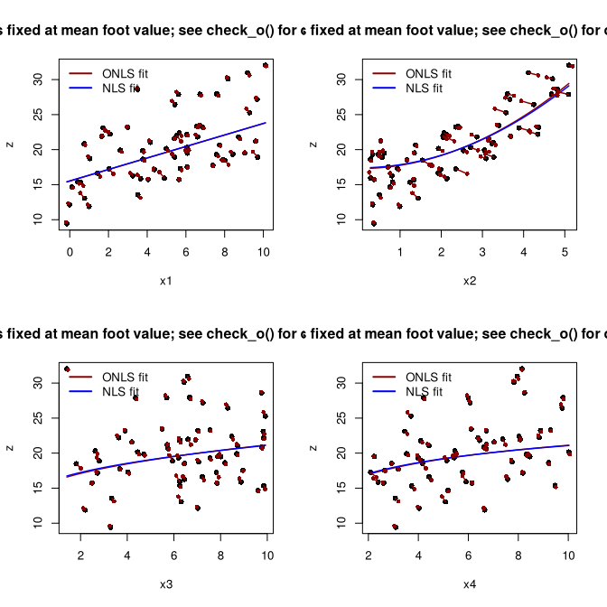

```r
plot(mod_mv)
```

Passing `panel` renders a single predictor as one full-size plot instead, with the same 1:1 aspect treatment as the univariate case – by position or by name:

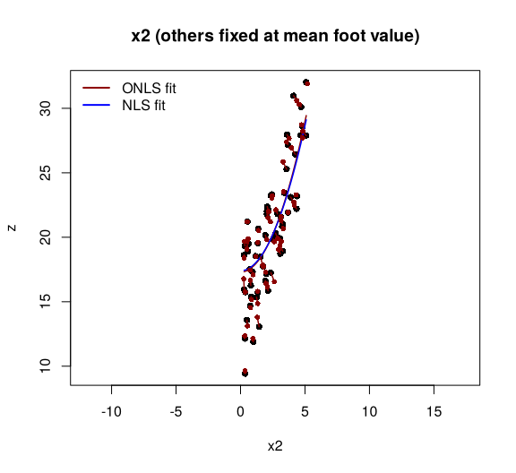

```r
plot(mod_mv, panel = "x2")
```

### 6.1 Correlated predictor errors: a full covariance matrix

If the predictor errors are correlated, `sigma_x` can be a full $p \times p$ covariance matrix $\Sigma_x$. For a *linear* model this problem has a closed-form solution, the generalized Total Least Squares (TLS) estimate: whitening the predictors with the Cholesky factor $L$ of the precision matrix ($L^T L = \Sigma_x^{-1}$) and scaling $y$ by $1/\sigma_y$ turns it into plain TLS, which is solved by a singular value decomposition. This gives an exact reference for `onls()`:

```r
set.seed(2026)
n <- 40
Sigma <- matrix(c(0.25, 0.15, 0.15, 0.16), 2)     # correlation of predictor errors = 0.75
sigma_y <- 0.3
xt <- cbind(runif(n, 0, 10), runif(n, 0, 10))
E <- matrix(rnorm(2 * n), n) %*% chol(Sigma)
DAT_cov <- data.frame(x1 = xt[, 1] + E[, 1], x2 = xt[, 2] + E[, 2],
                      y = 3 + 1.5 * xt[, 1] - 0.8 * xt[, 2] + rnorm(n, 0, sigma_y))

mod_cov <- onls(y ~ b0 + b1 * x1 + b2 * x2, data = DAT_cov,
                start = list(b0 = 1, b1 = 1, b2 = 1), sigma_x = Sigma, sigma_y = sigma_y,
                control = list(ftol = 1e-13, ptol = 1e-13))

## closed-form generalized TLS
L <- chol(solve(Sigma))
U <- as.matrix(DAT_cov[, c("x1", "x2")]) %*% t(L)      # whitened predictors
v <- DAT_cov$y / sigma_y
Z <- cbind(scale(U, scale = FALSE), v - mean(v))
V <- svd(Z)$v[, 3]
w <- -V[1:2] / V[3]
gTLS <- c(sigma_y * (mean(v) - sum(w * colMeans(U))), sigma_y * drop(t(L) %*% w))
print(data.frame(gen_TLS = gTLS, onls = coef(mod_cov),
                 abs_diff = abs(gTLS - coef(mod_cov))))   # all equal
```

```
#>       gen_TLS       onls     abs_diff
#> b0  3.2925307  3.2925307 1.146137e-08
#> b1  1.5044330  1.5044330 1.035817e-09
#> b2 -0.8344564 -0.8344564 1.412917e-09
```

Ignoring the correlation (a diagonal `sigma_x` only) gives visibly different estimates:

```r
mod_cov_d <- onls(y ~ b0 + b1 * x1 + b2 * x2, data = DAT_cov,
                  start = list(b0 = 1, b1 = 1, b2 = 1), sigma_x = sqrt(diag(Sigma)),
                  sigma_y = sigma_y)
coef(mod_cov_d)
```

```
#>         b0         b1         b2
#>  3.3853065  1.5012131 -0.8494335
```

## 7. Special cases

Two well-known linear methods are recovered exactly as special cases of `onls()`.

### 7.1 Deming regression

Deming regression – a linear model with known (or assumed) ratio of the predictor/response error variances – is just `onls()` with a linear formula and appropriate `sigma_x`/`sigma_y`, as in the Pearson-York example above. With the default equal error variances it is orthogonal regression; the example below reproduces the XLSTAT Deming regression demonstration (XLSTAT help article “Run a Deming regression to compare methods”, now in the Lumivero XLSTAT knowledge base):

```r
x <- c(9.8, 9.7, 10.7, 10.9, 12.4, 12.5, 12.8, 12.8, 12.9, 13.3,
       13.4, 13.5, 13.7, 14.9, 15.2, 15.5)
y <- c(10.1, 11.4, 10.8, 11.3, 11.8, 12.1, 12.3, 13.6, 14.2, 14.4,
       14.6, 15.3, 15.5, 15.8, 16.2, 16.5)
DAT_dem <- data.frame(x, y)

mod_dem <- onls(y ~ a + b * x, data = DAT_dem, start = list(a = 2, b = 3))
print(mod_dem)   # -1.909 / 1.208 as on the webpage
```

```
#> Nonlinear orthogonal regression model
#>   model: y ~ a + b * x
#>    data: DAT_dem
#>      a      b
#> -1.909  1.208
#>  vertical residual sum-of-squares: 9.224
#>  orthogonal residual sum-of-squares: 3.751
#>  PASSED: 16 out of 16 fitted points are orthogonal.
#>
#> Number of iterations to convergence: 9
#> Convergence tolerance (ftol): 1e-10
```

### 7.2 Total Least Squares

Total Least Squares (unweighted, multivariate, linear) is recovered by an unweighted linear `onls()` fit. Here we compare it against the closed-form SVD solution of Golub & Van Loan (1980):

```r
tls_fit <- function(X, y) {
  X <- as.matrix(X)
  p <- ncol(X)
  Xc <- scale(X, center = TRUE, scale = FALSE)
  yc <- y - mean(y)
  xbar <- colMeans(X); ybar <- mean(y)
  SVD <- svd(cbind(Xc, yc))
  v <- SVD$v[, p + 1L]
  slope <- -v[1:p] / v[p + 1L]
  list(intercept = ybar - sum(slope * xbar), slope = setNames(slope, colnames(X)))
}

set.seed(11)
n <- 40
x1_true <- runif(n, 0, 10)
x2_true <- runif(n, 0, 10)
y_true  <- 3 + 1.5 * x1_true - 0.8 * x2_true
DAT_tls <- data.frame(x1 = x1_true + rnorm(n, 0, 0.5),
                      x2 = x2_true + rnorm(n, 0, 0.5),
                      y  = y_true  + rnorm(n, 0, 0.5))

TLS <- tls_fit(DAT_tls[, c("x1", "x2")], DAT_tls$y)
mod_tls <- onls(y ~ b0 + b1 * x1 + b2 * x2, data = DAT_tls,
                start = list(b0 = 1, b1 = 1, b2 = 1))
TLS_vec  <- c(b0 = TLS$intercept, b1 = TLS$slope[["x1"]], b2 = TLS$slope[["x2"]])
ONLS_vec <- coef(mod_tls)[c("b0", "b1", "b2")]
print(data.frame(TLS_closed_form = TLS_vec, onls = ONLS_vec,
                 abs_diff = abs(TLS_vec - ONLS_vec)))   # equal to solver tolerance
```

```
#>    TLS_closed_form       onls     abs_diff
#> b0        3.681744  3.6817440 4.529555e-07
#> b1        1.468923  1.4689227 2.333856e-09
#> b2       -0.923844 -0.9238439 1.007331e-07
```